# Schizophrénie

### La Schizophrénie

Un test d’activité cérébrale est réalisé sur un patient quotidiennement durant 120 jours. Au jour 60, les médécins lui prescrivent le médicament.

Le nouveau médicament a t’il un effet sur l’activité cérébrale du patient étudié ?

> Jeu de données : schizo.txt

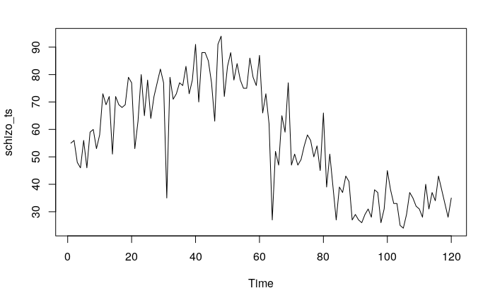

`r`r ## Identification de tendance à long terme # Tendance globale library(pastecs)

# Test classique de signification du coefficient de Spearman (moins adapté pour les ts!)

trend.test(schizo_ts)

```
Cannot compute exact p-value with ties

    Spearman's rank correlation rho

data:  schizo_ts and time(schizo_ts)
S = 476560, p-value = 4.946e-16
alternative hypothesis: true rho is not equal to 0
sample estimates:
       rho
-0.6548362
```

schizo_trend_test <- trend.test(schizo_ts, R = 999) # Même test, mais par bootstrap (mieux!) => R = 999, rééchantillonage 999x, sachant qu’il y a en une qui est la serie initiale; pour un totale de 1000. #doit exister une correlation significative entre les observations et le temps en présence d’une tendance. Mais comme les données ne sont pas indépendantes entre elles

BLOCK BOOTSTRAP FOR TIME SERIES

Fixed Block Length of 1

Call: boot::tsboot(tseries = x, statistic = test.trend, R = R, l = 1, sim = )

plot(schizo_trend_test)

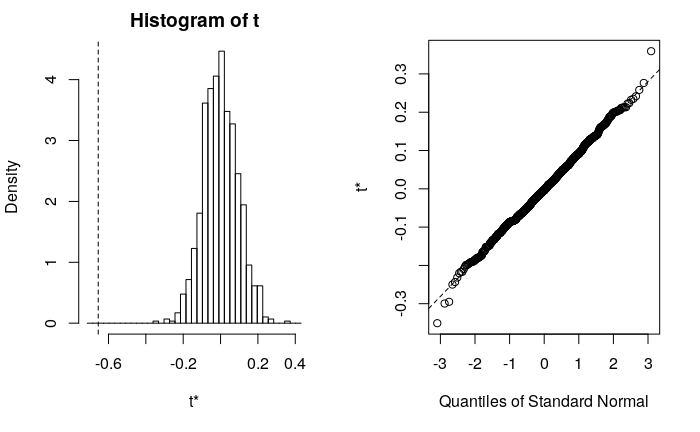

`r`r #histogramme: distibution de p bootstrapée, pointille = valeur du coeff de corrélation observé dans la série non réechantillone. plus le pointillé est extreme à gauche ou à droite dans la série plus on a tendance à penser que Ho est moins plausible=> tendance à rejetter Ho (=pas de tendance globale). p calculé grâce a l’air sous la courbe (qui relierait les sommets de tous les barres verticales de l’histogramme) aux extremités du pointillé. La droite verticale pointillée est à l’extreme gauche (tendance à penser qu’il y a une tendance générale déjà dan sla série initiale), d’où la faible valeur de p; p<alpha==> on rejette Ho: il y a une tendance générale. #quantile-quantile pour voir si la distibution boostrapée se rapproche d’une distribution normal ou pas. Reponse=OUI si les observations (ronds noirs) suivent la droite en pointillé. C’est bien le cas ici exception faite des premières et des dernières observations.

schizo_trend_test$p.value

```
[1] 0
```

`r`r # Valeur p associée au test bootstrappé# 0 -> Il y a bel et bien une tendance significative au seuil alpha de 5%.

[figure not shown]

[figure not shown]

`r`r # Analyse des résidus schizo.avg.resid <- extract(schizo.avg, components = ) is.ts(schizo.avg.resid) # Oui

```
[1] TRUE
```

`r`r is.mts(schizo.avg.resid) # Non

```
[1] FALSE
```

`r`r plot(schizo.avg.resid)

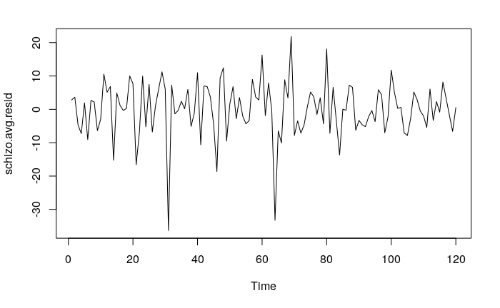

`r`r # Analyse acf(schizo.avg.resid)

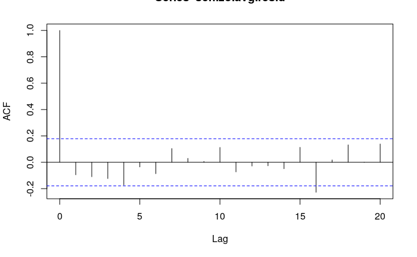

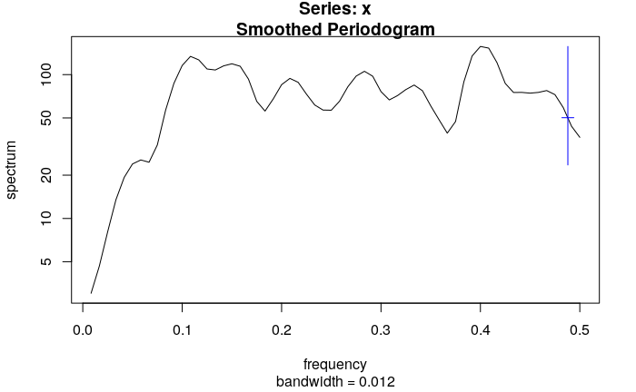

`r`r (schizo.avg.resid.trend <- trend.test(schizo.avg.resid, R = 999))

```
BLOCK BOOTSTRAP FOR TIME SERIES

Fixed Block Length of 1

Call:
boot::tsboot(tseries = x, statistic = test.trend, R = R, l = 1,
    sim = \fixed\)


Bootstrap Statistics :
       original     bias    std. error
t1* -0.07085909 0.06944631  0.09328789
```

`r`r plot(schizo.avg.resid.trend)

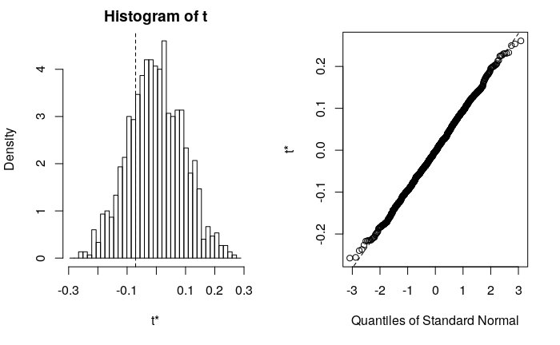

`r`r #pour l’analyse spectral on au cycle si la courbe monte jusqu’au traits bleus (vertical et horizontal qui se croisent) et puis il redescend. Ici on voit des cycles mais quand on interprète en biologie, on se rend compte que un cycle tous les 10 jours, 5 jours.. schizo.avg.resid.trend$p.value

```
[1] 0.4594595
```

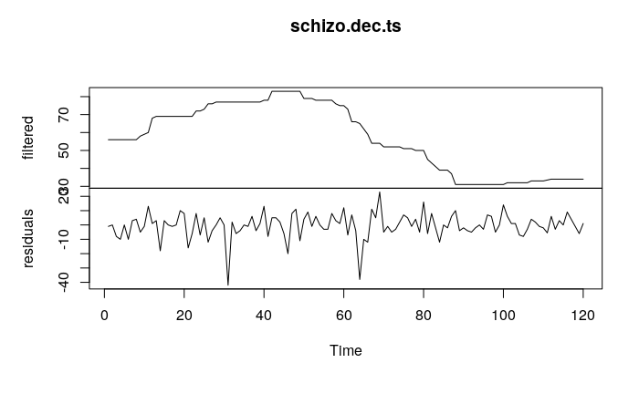

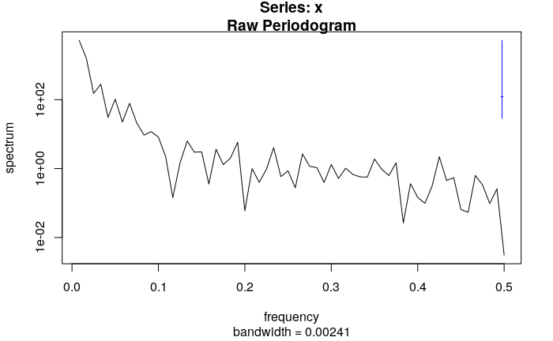

`r`r #Analyse schizo.dec.ts <- tseries(schizo.dec) # Extraire série de schizo diff plot(schizo.dec.ts) # Transforme toute les composante #calcul de deux séries: filtrée et résidus spectrum(schizo.dec.ts[, 1])

# Spectre de la première série (la série filtrée)

`r`r ## Méthode des différences pour enlever l’effet de la tendance generale: TESTER PLUSIEURS DECALAGES. (schizo.dif <- tsd(schizo_ts, lag = 1, order = 3, method = ))

```
 Call:
 decdiff(x = x, type = type, lag = lag, order = order, ends = ends)

Components
[1] \filtered\  \residuals\
```

`r`r plot(schizo.dif, col = 1:3)

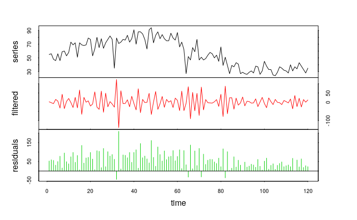

`r`r #on peut voir que la tendance generale a ete enleve de la serie filtree, en effet, la signal ne tend pas a diminuer, il suit une droite horizontale. Par contre dans les residus ont peut voir que le signal est moins intense quand le temps augmente.

#OU

(schizo.dif1 <- tsd(schizo_ts, lag = 3, order = 3, method = ))

```
 Call:
 decdiff(x = x, type = type, lag = lag, order = order, ends = ends)

Components
[1] \filtered\  \residuals\
```

`r`r plot(schizo.dif1, col = 1:3)

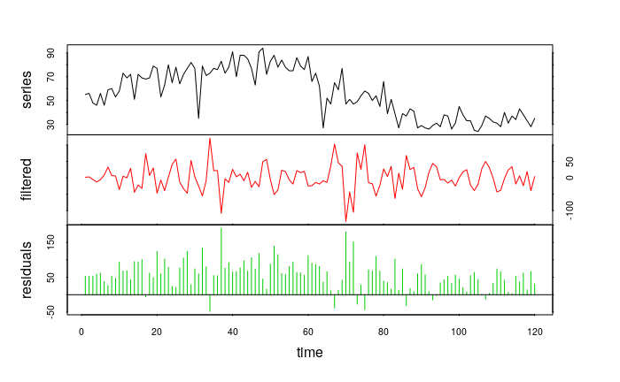

`r`r

spectrum(schizo_ts)

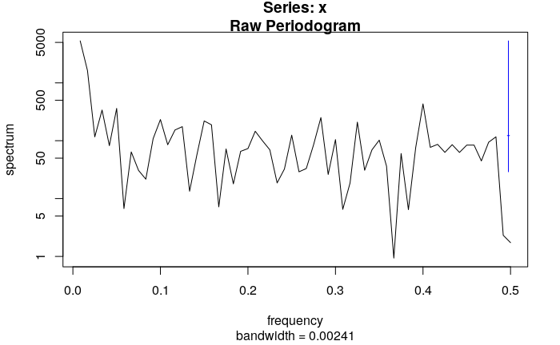

`r`r # Spectre de schizo_ts schizo.dif.ts <- tseries(schizo.dif) # Extraire série de schizo diff : pour verifier qd on extrait la tendance qu’on la bien extraite. si on extrait les residus c’est pour voir s’il ne reste plus de tendance. plot(schizo.dif.ts)

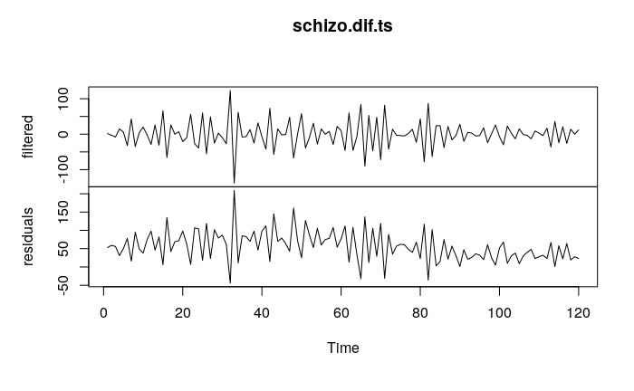

`r`r # Transforme toute les composante #calcul de deux séries: filtrée et résidus spectrum(schizo.dif.ts[, 1])

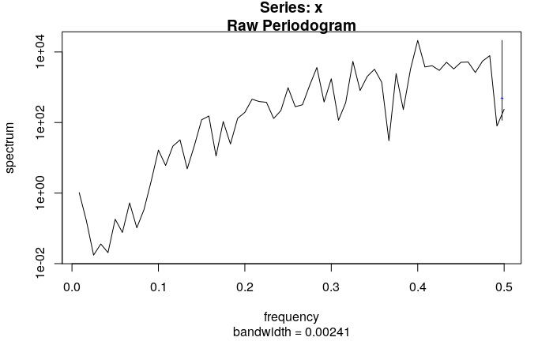

`r`r # Spectre de la première série (la série filtrée)